# How do Air Pollutants Affect PM2.5 in NY State

Yutong_Wu

11/28/2019

## 1. Project Overview

Air pollution is one of the most significant environmental problem in New York and causes more than 3000 death yearly. (according to [NYC Health] (https://www1.nyc.gov/assets/doh/downloads/pdf/eode/eode-air-quality-impact.pdf))

This project aims to evaluate the air quality (measured by pm2.5) by different counties in NY state and investigate how air pollutant (CO, NO2, O3, SO2) contribute to the air pollution (pm2.5).

## 2. Predict Air Quality and Predictors Analysis

The data is downloaded from [EPA] (https://www.epa.gov/outdoor-air-quality-data/download-daily-data). We use daily data in 2018.

#### 2.1 Dataset

```r
require (tidyr)
require (tidyverse)
require (caret)
require (recipes)
```

Read the csv file of the 5 pollutants data.

```r
data_PM <- read.csv (file = "NY_air_Data/pm2.5_2018.csv")
data_NO2 <- read.csv (file = "NY_air_Data/no2_2018.csv")
data_CO <- read.csv (file = "NY_air_Data/co_2018.csv")
data_SO2 <- read.csv (file = "NY_air_Data/so2_2018.csv")
data_O3 <- read.csv (file = "NY_air_Data/o3_2018.csv")

head (data_PM)
```

|  | Date | Source | Site.ID | POC | Daily.Mean.PM2.5.Concentration | UNITS | DAILY_AQI_VALUE | Site.Name | DAILY_OBS_COUNT | PERCENT_COMPLETE | AQS_PARAMETER_CODE | AQS_PARAMETER_DESC | CBSA_CODE | CBSA_NAME | STATE_CODE | STATE | COUNTY_CODE | COUNTY | SITE_LATITUDE | SITE_LONGITUDE |
| --- | --- | --- | --- | --- | --- | --- | --- | --- | --- | --- | --- | --- | --- | --- | --- | --- | --- | --- | --- | --- |
| 1 | 1/2/2018 | AQS | 360010005 | 1 | 8.5 | ug/m3 LC | 35 | ALBANY COUNTY HEALTH DEPT | 1 | 100 | 88101 | PM2.5 - Local Conditions | 10580 | Albany-Schenectady-Troy, NY | 36 | New York | 1 | Albany | 42.64225 | -73.75464 |
| 2 | 1/5/2018 | AQS | 360010005 | 1 | 2.7 | ug/m3 LC | 11 | ALBANY COUNTY HEALTH DEPT | 1 | 100 | 88101 | PM2.5 - Local Conditions | 10580 | Albany-Schenectady-Troy, NY | 36 | New York | 1 | Albany | 42.64225 | -73.75464 |
| 3 | 1/8/2018 | AQS | 360010005 | 1 | 13.9 | ug/m3 LC | 55 | ALBANY COUNTY HEALTH DEPT | 1 | 100 | 88101 | PM2.5 - Local Conditions | 10580 | Albany-Schenectady-Troy, NY | 36 | New York | 1 | Albany | 42.64225 | -73.75464 |
| 4 | 1/11/2018 | AQS | 360010005 | 1 | 10.8 | ug/m3 LC | 45 | ALBANY COUNTY HEALTH DEPT | 1 | 100 | 88101 | PM2.5 - Local Conditions | 10580 | Albany-Schenectady-Troy, NY | 36 | New York | 1 | Albany | 42.64225 | -73.75464 |
| 5 | 1/14/2018 | AQS | 360010005 | 1 | 4.5 | ug/m3 LC | 19 | ALBANY COUNTY HEALTH DEPT | 1 | 100 | 88101 | PM2.5 - Local Conditions | 10580 | Albany-Schenectady-Troy, NY | 36 | New York | 1 | Albany | 42.64225 | -73.75464 |
| 6 | 1/17/2018 | AQS | 360010005 | 1 | 19.9 | ug/m3 LC | 67 | ALBANY COUNTY HEALTH DEPT | 1 | 100 | 88101 | PM2.5 - Local Conditions | 10580 | Albany-Schenectady-Troy, NY | 36 | New York | 1 | Albany | 42.64225 | -73.75464 |

Select the columns that we need.

```r
data_pm2.5 <- data_PM %>%
  select (Date, daily.pm2.5 = Daily.Mean.PM2.5.Concentration, COUNTY, Site.Name)

data_no2 <- data_NO2 %>%
  select (Date, daily.no2 = Daily.Max.1.hour.NO2.Concentration, COUNTY, Site.Name)
data_so2 <- data_SO2 %>%
  select (Date, daily.so2 = Daily.Max.1.hour.SO2.Concentration, COUNTY, Site.Name)
data_co <- data_CO %>%
  select (Date, daily.co = Daily.Max.8.hour.CO.Concentration, COUNTY, Site.Name)
data_o3 <- data_O3 %>%
  select (Date, daily.o3 = Daily.Max.8.hour.Ozone.Concentration, COUNTY, Site.Name)
```

Since SO2 and NO2 is measured by ppb, which is different from the unit of CO and O3 (ppm) I transform the unit of SO2 and NO2 from ppb to ppm by dividing the value by 1000.

```r
data_so2$daily.so2 <-  data_so2$daily.so2/1000
data_no2$daily.no2 <-  data_no2$daily.no2/1000
```

Merge all the data into one dataset using full_join.

```r
data_emission <- full_join(data_pm2.5, data_co, by = c( "Date", "COUNTY", "Site.Name" ))
data_emission <- full_join(data_emission, data_no2, by = c( "Date", "COUNTY", "Site.Name" ))
data_emission <- full_join(data_emission, data_o3, by = c( "Date", "COUNTY", "Site.Name" ))
data_emission <- full_join(data_emission, data_so2, by = c( "Date", "COUNTY", "Site.Name" ))
head (data_emission)
```

|  | Date | daily.pm2.5 | COUNTY | Site.Name | daily.co | daily.no2 | daily.o3 | daily.so2 |
| --- | --- | --- | --- | --- | --- | --- | --- | --- |
| 1 | 1/2/2018 | 8.5 | Albany | ALBANY COUNTY HEALTH DEPT | NA | NA | NA | NA |
| 2 | 1/5/2018 | 2.7 | Albany | ALBANY COUNTY HEALTH DEPT | NA | NA | NA | NA |
| 3 | 1/8/2018 | 13.9 | Albany | ALBANY COUNTY HEALTH DEPT | NA | NA | NA | NA |
| 4 | 1/11/2018 | 10.8 | Albany | ALBANY COUNTY HEALTH DEPT | NA | NA | NA | NA |
| 5 | 1/14/2018 | 4.5 | Albany | ALBANY COUNTY HEALTH DEPT | NA | NA | NA | NA |
| 6 | 1/17/2018 | 19.9 | Albany | ALBANY COUNTY HEALTH DEPT | NA | NA | NA | NA |

Dealing with Missing value by removing observations that contain N/A and check out how many observation we now have.

```r
data_emission_omitna <-
  na.omit (data_emission)
head (data_emission_omitna)
```

|  | Date | daily.pm2.5 | COUNTY | Site.Name | daily.co | daily.no2 | daily.o3 | daily.so2 |
| --- | --- | --- | --- | --- | --- | --- | --- | --- |
| 1579 | 1/2/2018 | 8.9 | Bronx | PFIZER LAB SITE | 0.4 | 0.0272 | 0.023 | 0.0031 |
| 1580 | 1/5/2018 | 5.6 | Bronx | PFIZER LAB SITE | 0.3 | 0.0143 | 0.031 | 0.0015 |
| 1581 | 1/8/2018 | 20.7 | Bronx | PFIZER LAB SITE | 0.5 | 0.0440 | 0.006 | 0.0117 |
| 1582 | 1/11/2018 | 24.0 | Bronx | PFIZER LAB SITE | 1.2 | 0.0539 | 0.003 | 0.0047 |
| 1583 | 1/14/2018 | 4.7 | Bronx | PFIZER LAB SITE | 0.3 | 0.0109 | 0.031 | 0.0045 |
| 1584 | 1/17/2018 | 12.8 | Bronx | PFIZER LAB SITE | 0.5 | 0.0264 | 0.019 | 0.0018 |

```r
nrow(data_emission_omitna)
```

```
## [1] 759
```

We have in total 759 unique observations in total. Each observation of a dataset is represented in a unique row, thus the data is tidy.

#### 2.2 Machine Learning - Run Regression model to predict Air Pollution (pm2.5)

- Step 1. Split the data into a training and test dataset partitioning 75% of the data into the training data, and holding out 25% of the data as a test set

```r
set.seed (123)
index = createDataPartition (data_emission_omitna $ daily.pm2.5, p = .75, list = F)  # list = FALSE avoids returns the data as a list.
train_data <-
  data_emission_omitna [index, ]
test_data <-
  data_emission_omitna [-index, ]
dim (train_data)
```

```
## [1] 570   8
```

```r
dim (test_data)
```

```
## [1] 189   8
```

- Step 2. Exam the data

Transform the date variable from character into data.

```r
train_data <-
 train_data %>%
  mutate (Date = lubridate::mdy(Date))
test_data <-
  test_data %>%
  mutate (Date = lubridate::mdy(Date))
```

```r
skimr :: skim (train_data)
```

|  | variable | type | stat | level | value | formatted |
| --- | --- | --- | --- | --- | --- | --- |
| 1 | Date | Date | missing | .all | 0.000000e+00 | 0 |
| 2 | Date | Date | complete | .all | 5.700000e+02 | 570 |
| 3 | Date | Date | n | .all | 5.700000e+02 | 570 |
| 4 | Date | Date | min | .all | 1.753200e+04 | 2018-01-01 |
| 5 | Date | Date | max | .all | 1.789500e+04 | 2018-12-30 |
| 6 | Date | Date | median | .all | 1.770700e+04 | 2018-06-25 |
| 7 | Date | Date | n_unique | .all | 3.240000e+02 | 324 |
| 8 | daily.pm2.5 | numeric | missing | .all | 0.000000e+00 | 0 |
| 9 | daily.pm2.5 | numeric | complete | .all | 5.700000e+02 | 570 |
| 10 | daily.pm2.5 | numeric | n | .all | 5.700000e+02 | 570 |

[output cut: 66 more lines]

Visualize the distribtion for each charactor variables.

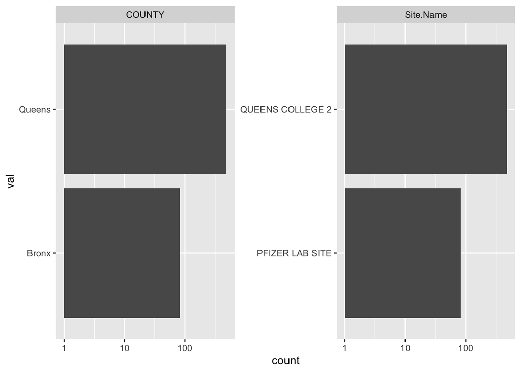

```r
train_data %>%
  select_if(is.character) %>%
  gather (var, val) %>%
  ggplot (aes(val)) +
    geom_bar() +
    scale_y_log10() +
    facet_wrap(~var,scales="free",ncol=3) +
    coord_flip()
```

Visualize the distribtion for each numerical variables.

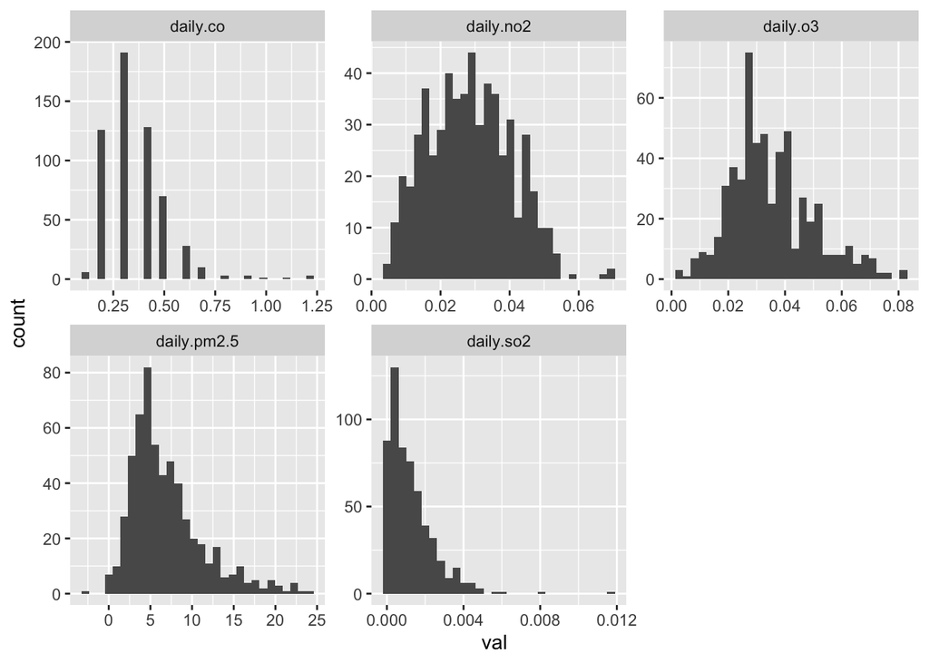

```r
train_data %>%
  select_if(is.numeric) %>%
  gather (var, val) %>%
  ggplot (aes(val, group = var)) +
   geom_histogram(bins = 30) +
   facet_wrap(~var, scales = "free", ncol = 3)
```

*`Skewness`*

From numerical value visualization, I found that daily.pm.2.5 (outcome) and daily.so2 are right skewed, with so2 data skewed more. So let’s look more into daily.so2.

```r
train_data_so2_conc <-
train_data %>%
  mutate (
    so2 = case_when(
    daily.so2 == 0 ~ "clean",
    daily.so2 > 0 & daily.so2 <= 0.002 ~ "low",
    daily.so2 > 0.002 & daily.so2 <= 0.004 ~ "Mid",
    daily.so2 > 0.004 & daily.so2 <= 0.006 ~ "High",
    daily.so2 > 0.006 ~ "SupHigh",)
    ) # %>%
  #mutate (so2, fct_infreq(so2))
head (train_data_so2_conc)
```

|  | Date | daily.pm2.5 | COUNTY | Site.Name | daily.co | daily.no2 | daily.o3 | daily.so2 | so2 |
| --- | --- | --- | --- | --- | --- | --- | --- | --- | --- |
| 1 | 2018-01-02 | 8.9 | Bronx | PFIZER LAB SITE | 0.4 | 0.0272 | 0.023 | 0.0031 | Mid |
| 2 | 2018-01-08 | 20.7 | Bronx | PFIZER LAB SITE | 0.5 | 0.0440 | 0.006 | 0.0117 | SupHigh |
| 3 | 2018-01-11 | 24.0 | Bronx | PFIZER LAB SITE | 1.2 | 0.0539 | 0.003 | 0.0047 | High |
| 4 | 2018-01-14 | 4.7 | Bronx | PFIZER LAB SITE | 0.3 | 0.0109 | 0.031 | 0.0045 | High |
| 5 | 2018-01-17 | 12.8 | Bronx | PFIZER LAB SITE | 0.5 | 0.0264 | 0.019 | 0.0018 | low |
| 6 | 2018-01-29 | 7.4 | Bronx | PFIZER LAB SITE | 0.4 | 0.0228 | 0.026 | 0.0011 | low |

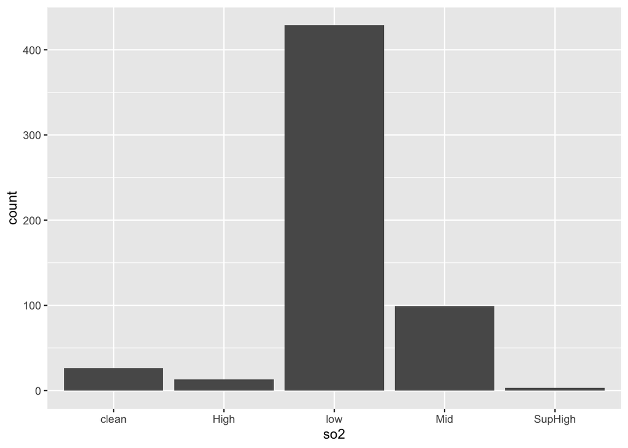

```r
train_data_so2_conc %>%
  ggplot (aes (so2)) +
    geom_bar()
```

```r
train_data %>%
  select (COUNTY, daily.so2) %>%
  filter (daily.so2 == 0) %>%
  group_by(COUNTY) %>%
  count(daily.so2)
```

| COUNTY | daily.so2 | n |
| --- | --- | --- |
| Queens | 0 | 26 |

Daily so2 in 0 in 26 days at Queens. I will investigate more into this in the project.

*`Range of the features and Responses`*

```r
list (
  PM2.5_Range = range (train_data$daily.pm2.5),
  CO_Range = range (train_data$daily.co),
  NO2_Range = range (train_data$daily.no2),
  O3_Range = range (train_data$daily.o3),
  SO2_Range = range (train_data$daily.so2))
```

```
## $PM2.5_Range
## [1] -2.9 24.0
##
## $CO_Range
## [1] 0.1 1.2
##
## $NO2_Range
## [1] 0.0040 0.0689
##
## $O3_Range
## [1] 0.003 0.082
##
## $SO2_Range
## [1] 0.0000 0.0117
```

- Step 3. Data Pre-processing

Deal with skewness

```r
train_data2 <-
  train_data %>%
    mutate(daily.so2 = log (daily.so2+1)) %>%
    mutate(daily.pm2.5 = log (daily.pm2.5 +1))
```

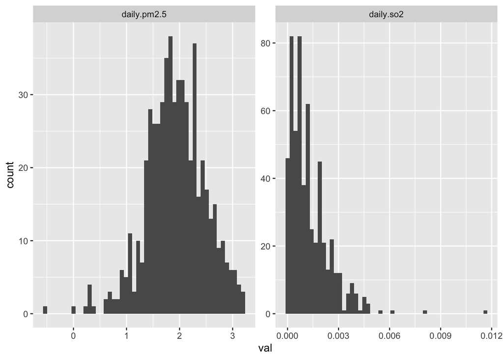

```r
test_data2 <-
  test_data %>%
    mutate(daily.so2 = log (daily.so2+1) ) %>%
    mutate(daily.pm2.5 = log (daily.pm2.5))


train_data2 %>%
  select (daily.so2, daily.pm2.5) %>%
  gather (var, val) %>%
  ggplot (aes(val)) +
    geom_histogram (bins = 50) +
    facet_wrap(~var, scales = "free", ncol = 3)
```

Then, build the recipe, transform nominal data into dummies, and scale all the vairable in order to compare.

```r
# Build a receipt
# install.packages("recipes")
require (recipes)
rcp <-
  recipe (daily.pm2.5 ~ . , train_data2) %>%
    step_dummy(all_nominal(), -all_outcomes()) %>%
    # Normalize Scale
    step_range (all_numeric()) %>%
    prep()

# Apply the recipe to the training and test data
train_data3 <- bake(rcp,train_data2)
test_data3 <- bake(rcp,test_data2)

head(train_data3)
```

| Date | daily.pm2.5 | daily.co | daily.no2 | daily.o3 | daily.so2 | COUNTY_Queens | Site.Name_QUEENS.COLLEGE.2 |
| --- | --- | --- | --- | --- | --- | --- | --- |
| 2018-01-02 | 0.7516313 | 0.2727273 | 0.3574730 | 0.25316456 | 0.26609203 | 0 | 0 |
| 2018-01-08 | 0.9620443 | 0.3636364 | 0.6163328 | 0.03797468 | 1.00000000 | 0 | 0 |
| 2018-01-11 | 1.0000000 | 1.0000000 | 0.7688752 | 0.00000000 | 0.40310828 | 0 | 0 |
| 2018-01-14 | 0.6036118 | 0.1818182 | 0.1063174 | 0.35443038 | 0.38599319 | 0 | 0 |
| 2018-01-17 | 0.8406824 | 0.3636364 | 0.3451464 | 0.20253165 | 0.15460531 | 0 | 0 |
| 2018-01-29 | 0.7075787 | 0.2727273 | 0.2896764 | 0.29113924 | 0.09451405 | 0 | 0 |

```r
list (
  PM2.5_Range = range (train_data3$daily.pm2.5),
  CO_Range = range (train_data3$daily.co),
  NO2_Range = range (train_data3$daily.no2),
  O3_Range = range (train_data3$daily.o3),
  SO2_Range = range (train_data3$daily.so2))
```

```
## $PM2.5_Range
## [1] NaN NaN
##
## $CO_Range
## [1] 0 1
##
## $NO2_Range
## [1] 0 1
##
## $O3_Range
## [1] 0 1
##
## $SO2_Range
## [1] 0 1
```

*`Outliers`*

Since the scale is now normalized, we can now examine the outliers. Visualize Outliers by boxplot.

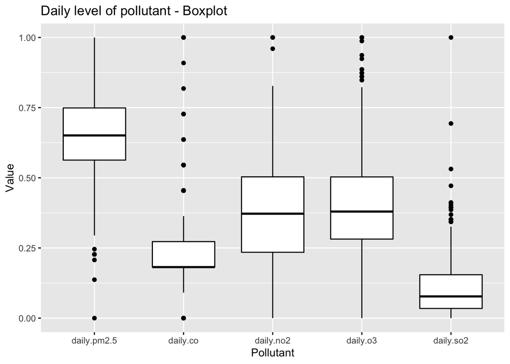

```r
train_data3 %>%
  gather (key = "Pollutant", value = "Value", -Date, -COUNTY_Queens, -Site.Name_QUEENS.COLLEGE.2) %>%
  group_by(Pollutant) %>%
  ggpubr :: ggboxplot (x = "Pollutant", y = "Value",
            palette = "aaas",
            title = "Daily level of pollutant - Boxplot ",
            ggtheme = theme_gray())
```

Before further step, I check the missing value one more time to make sure that there is no missing value.

```r
train_data3 <-
  na.omit (train_data3)
sum (is.na (train_data3$daily.pm2.5))
```

```
## [1] 0
```

- Step 4. Cross-Validation

Set cross-validation settings as an object that can be easily applied across different machine learning applications Use K-fold cross-validation method with 5 subsets.

```r
# set seed for replication
set.seed (1988)
# randomly dividing the data into 5 groups
folds <-
  createFolds (train_data3$daily.pm2.5, k = 5)

# check the length of each fold
sapply(folds,length)
```

```
## Fold1 Fold2 Fold3 Fold4 Fold5
##   112   114   114   116   113
```

```r
control_conditions <-
  trainControl(
    method = "cv",
    index = folds
    )
```

- Step 5. Build Model
  1. Linear Regression

```r
mod_lm <-
  train (
    daily.pm2.5 ~ . ,
    data = train_data3,
    method = "lm",
    metric = "RMSE",
    # cross validation conditions
    trControl = control_conditions
  )
mod_lm
```

```
## Linear Regression
##
## 569 samples
##   7 predictor
##
## No pre-processing
## Resampling: Cross-Validated (10 fold)
## Summary of sample sizes: 112, 114, 114, 116, 113
## Resampling results:
##
##   RMSE       Rsquared   MAE
##   0.1211462  0.3346572  0.0941161
##
## Tuning parameter 'intercept' was held constant at a value of TRUE
```

2. K-Nearest Neighbors

```r
mod_knn <-
  train (
    daily.pm2.5 ~ . ,
    data = train_data3,
    method = "knn",
    metric = "RMSE",
    trControl = control_conditions,
    # vary the tuning parameter k
    tuneGrid = expand.grid(k = c(1,5,10,50))
      )

mod_knn
```

```
## k-Nearest Neighbors
##
## 569 samples
##   7 predictor
##
## No pre-processing
## Resampling: Cross-Validated (10 fold)
## Summary of sample sizes: 112, 114, 114, 116, 113
## Resampling results across tuning parameters:
##
##   k   RMSE       Rsquared    MAE
##    1  0.1709318  0.10697965  0.1270834
##    5  0.1484055  0.07852581  0.1150257
##   10  0.1442295  0.08201192  0.1124182
##   50  0.1452687  0.03501542  0.1135665
##
## RMSE was used to select the optimal model using the smallest value.
## The final value used for the model was k = 10.
```

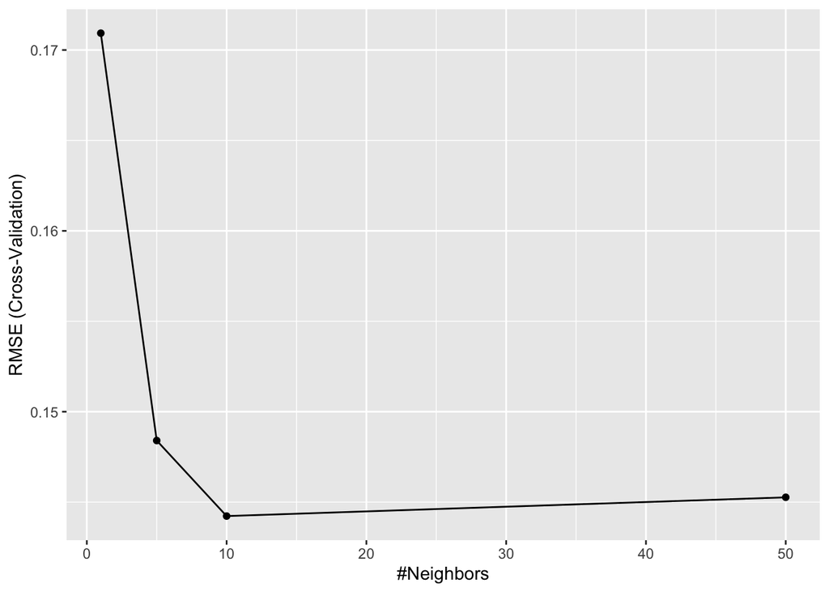

```r
ggplot (mod_knn)
```

```r
mod_knn$finalModel
```

```
## 10-nearest neighbor regression model
```

By adjusting the tunning parameters and we find that 10-neighbors performs best.

3. Random Forest

```r
mod_rf <-
  train (
    daily.pm2.5 ~ . ,
    data = train_data3,
    method = "ranger",
    metric = "RMSE",
    # for future comparison between variables
    importance = "permutation",
    trControl = control_conditions
    )
mod_rf
```

```
## Random Forest
##
## 569 samples
##   7 predictor
##
## No pre-processing
## Resampling: Cross-Validated (10 fold)
## Summary of sample sizes: 112, 114, 114, 116, 113
## Resampling results across tuning parameters:
##
##   mtry  splitrule   RMSE       Rsquared   MAE
##   2     variance    0.1050775  0.5037076  0.07987985
##   2     extratrees  0.1081171  0.4975146  0.08254847
##   4     variance    0.1062808  0.4813877  0.08079441
##   4     extratrees  0.1050450  0.5009244  0.08048050
##   7     variance    0.1081948  0.4618325  0.08214128
##   7     extratrees  0.1056405  0.4896534  0.08102085
##
## Tuning parameter 'min.node.size' was held constant at a value of 5
## RMSE was used to select the optimal model using the smallest value.
## The final values used for the model were mtry = 4, splitrule =
##  extratrees and min.node.size = 5.
```

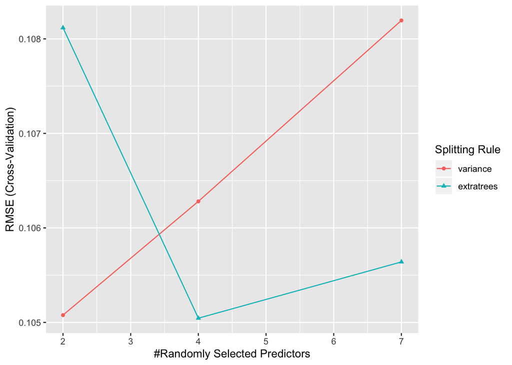

```r
ggplot (mod_rf)
```

```r
mod_rf $bestTune
```

|  | mtry | splitrule | min.node.size |
| --- | --- | --- | --- |
| 4 | 4 | extratrees | 5 |

```r
fm_rf <-
  mod_rf $ finalModel
fm_rf
```

```
## Ranger result
##
## Call:
##  ranger::ranger(dependent.variable.name = ".outcome", data = x,      mtry = min(param$mtry, ncol(x)), min.node.size = param$min.node.size,      splitrule = as.character(param$splitrule), write.forest = TRUE,      probability = classProbs, ...)
##
## Type:                             Regression
## Number of trees:                  500
## Sample size:                      569
## Number of independent variables:  7
## Mtry:                             4
## Target node size:                 5
## Variable importance mode:         permutation
## Splitrule:                        extratrees
## OOB prediction error (MSE):       0.008239125
## R squared (OOB):                  0.6205612
```

- *‘Model Comparison’*

```r
mod_list <-
  list (
    lm = mod_lm,
    knn = mod_knn,
    rf = mod_rf
  )

# Resamples in order to make comparison
resamples(mod_list)
```

```
##
## Call:
## resamples.default(x = mod_list)
##
## Models: lm, knn, rf
## Number of resamples: 5
## Performance metrics: MAE, RMSE, Rsquared
## Time estimates for: everything, final model fit
```

- Examine the error across models.

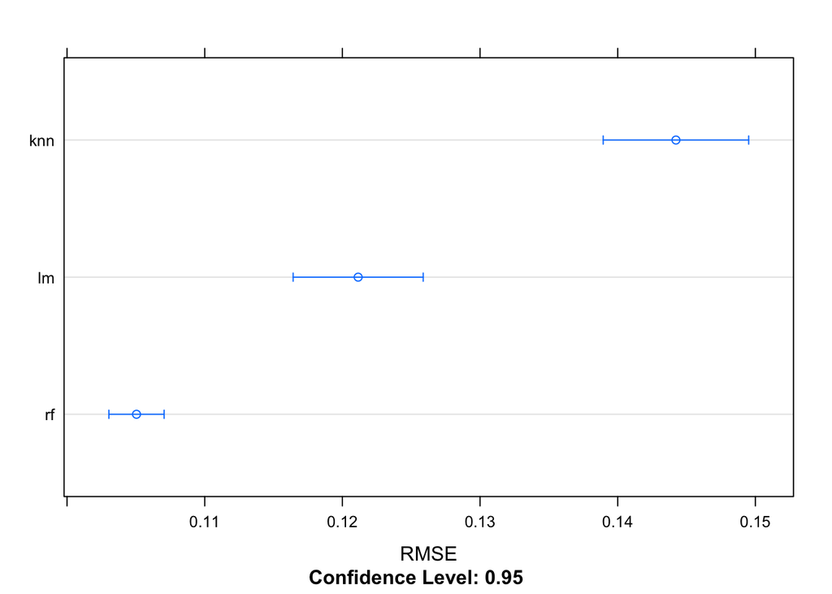

```r
dotplot (resamples(mod_list), metric = "RMSE")
```

- Examine the fit across models.

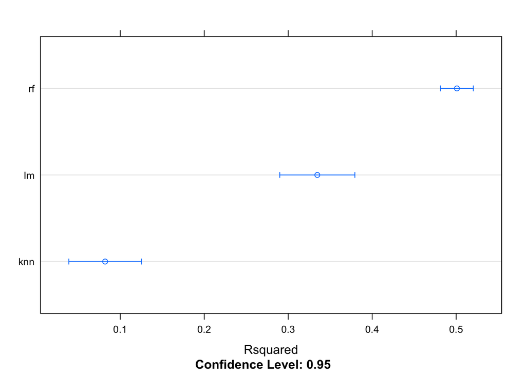

```r
dotplot (resamples(mod_list), metric = "Rsquared")
```

- Test the predictive accuracy of the best model.

```r
pred_y <-
  predict(mod_rf, newdata = test_data3)
```

- Calculate the Mean Squared Error of the best model.

```r
mse = sum((pred_y - test_data3$daily.pm2.5)^2) / nrow(test_data3)
mse
```

```
## [1] 0.01376321
```

#### 2.3 Variable Importance

- Preditors Importance.

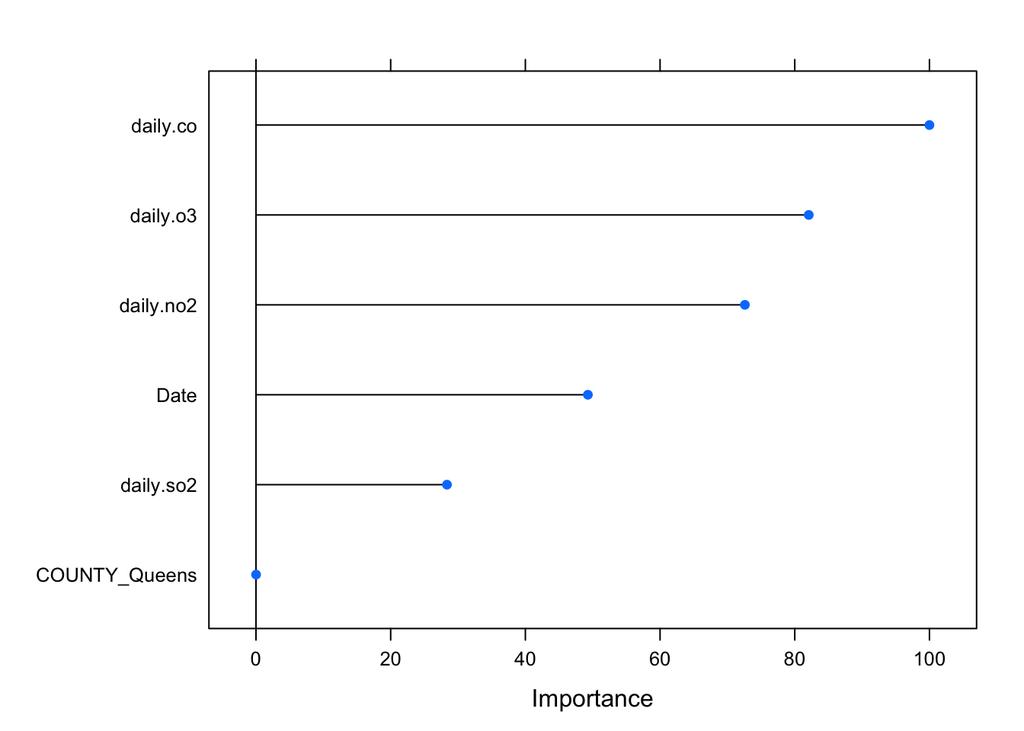

```r
plot(varImp(mod_rf,scale=T),top = 6)
```

### 3. Rank of Air Pollution of Different Counties in 2018

- Which County is the most polluted in 2018?

```r
data_emission_county <-
  data_emission %>%
  select (Date, daily.pm2.5, COUNTY) %>%
  group_by (COUNTY) %>%
  na.omit (.) %>%
  summarise (mean_daily_pm2.5 = mean(daily.pm2.5), var_daily_pm2.5 = var(daily.pm2.5) ) %>%
  arrange(desc(mean_daily_pm2.5)) %>%
  top_n(10)
data_emission_county
```

| COUNTY | mean_daily_pm2.5 | var_daily_pm2.5 |
| --- | --- | --- |
| New York | 8.081954 | 20.36803 |
| Richmond | 7.634857 | 18.99303 |
| Erie | 7.512825 | 15.44433 |
| Bronx | 7.185673 | 20.32565 |
| Albany | 7.094753 | 16.46137 |
| Queens | 6.775636 | 16.57421 |
| Monroe | 6.609705 | 15.64312 |
| Chautauqua | 6.572650 | 19.69045 |
| Orange | 6.017300 | 19.09129 |
| Nassau | 5.979452 | 16.24664 |

### 4. In the future …

- Dig more into the influence of skewness and outliers
- Investigate the 0 value of predictors SO2
- Involve more economic features if possible